# 港.股.迷.惑.行.为.大.赏

Yunlong(@algorithmx)

```r
knitr::opts_chunk$set(echo = TRUE)
library(ggplot2)
library(Quandl)
library(fBasics)
library(timeSeries)
library(tidyr)
library(lubridate)
library(dplyr)
library(goft)
library(readxl)
library(comprehenr)
library(stringr)
library(fitdistrplus)
```

这篇笔记主要讨论港交所列出的当前可交易股票，是一系列探讨资产定价模型CAPM文章的第一篇。这是一篇严肃的笔记，部分内容曾作为相关课程作业。

# 数据

## 数据源

有几个地方可以获得免费数据：

1. Akshare https://www.akshare.xyz/index.html
2. [Nasdaq Data Link](https://data.nasdaq.com/data/HKEX-hong-kong-exchange) 配合 R library `Quandl`
3. 网站 stooq.com https://stooq.com/db/h/

这篇笔记使用数据源3。如果你想运行程序，需要先从stooq.com下载所有港交所数据。

## 抽查

首先我们抽查一下stooq的数据，确认它的数据质量大致合格。做法是用`Quandl`来下载 Nasdaq Data Link 的数据，然后与 stooq 数据画图比对。

```r
# 下载和加载数据
df1 <- Quandl("HKEX/00019")
hk00005_nasdata <- data.frame(
  date=as.Date(df1$Date,format="%Y-%m-%d"),
  close=df1$`Nominal Price`)
df2 <- read.csv('hk/hkex_stocks/19.hk.txt')
hk00005_stooqdata <- data.frame(
  date=as.Date(as.character(df2$X.DATE.),format=("%Y%m%d")),
  close=df2$X.CLOSE.)
```

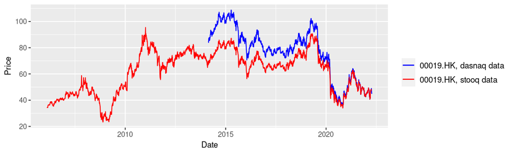

```r
# 画图
p <-  ggplot() +
      geom_line(data=hk00005_nasdata,aes(x=date,y=close,color='00019.HK, dasnaq data')) +
      geom_line(data=hk00005_stooqdata,aes(x=date,y=close,color='00019.HK, stooq data')) +
      labs(x="Date", y="Price") +
      scale_color_manual(name='',
                         breaks=c('00019.HK, dasnaq data',
                                  '00019.HK, stooq data'),
                         values=c('00019.HK, dasnaq data'='blue',
                                  '00019.HK, stooq data'='red')) +
      theme(legend.title=element_text(size=10),
            legend.text=element_text(size=10),
            legend.position = "right",
            axis.title.x = element_text(size=10),
            axis.title.y = element_text(size=10))
p
```

## stooq 数据基本信息

来看一下从 stooq 下载到的港交所股票数据的基本情况。总共有2234支股票信息：

```r
all_files   <- list.files(path="./hk/hkex_stocks/")
length(all_files)
```

```
[1] 2234
```

为了之后方便，我们来做一个加载函数：

```r
# 加载stooq文件
load_hk_stooq <- function(fn){
  df <- read.csv(fn)
  df <- data.frame(
    date=as.Date(as.character(df$X.DATE.),format=("%Y%m%d")),
    close=as.numeric(df$X.CLOSE.),
    volume=as.numeric(df$X.VOL.))
  return(df)
}
```

现在加载所有数据：

```r
stocks_all <- list()
for (f in all_files){
  df <- load_hk_stooq(paste0("./hk/hkex_stocks/",f))
  stocks_all <- append(stocks_all, list(df))
}
```

我们看看 stooq 交易日股价数据最早、最晚分别到什么日期：

```r
min(to_vec(for (st in stocks_all) as.character(min(st$date))))
```

```
[1] "2005-10-13"
```

```r
max(to_vec(for (st in stocks_all) as.character(max(st$date))))
```

```
[1] "2022-04-01"
```

由于下载日期不同，你看到的图线、日期可能略有不同。

# 统计

下面我们对股价历史数据的各项指标进行统计。对于各种例外，我们将展示其“迷惑行为”。 为了与之后的CAPM模型检验的工作衔接，我们首先将股价按月平均，并将时间起止设定为 2006年02月01日（或上市日期）至2021年12月31日，然后再对月度数据进行统计。

```r
# 日期限定
start_date <- as.Date("2006-02-01")
end_date <- as.Date("2021-12-31")
# 转化成月度数据
convert_to_monthly <- function(df){
  # add column "month"
  df1 <- data.frame(
    date=as.Date(df$date),
    close=as.numeric(df$close),
    volume=as.numeric(df$volume),
    month=floor_date(df$date,"month"))
  # monthly average/min/max price and total volume
  df2 <- df1 %>%
    group_by(month) %>%
    summarize(close=mean(close,na.rm=TRUE),
              closemin=min(close,na.rm=TRUE),
              closemax=max(close,na.rm=TRUE),
              volume=sum(volume,na.rm=TRUE)) %>%
    as.data.frame
  # select date within range
  df3 <- df2[start_date<=df2$month & end_date>=df2$month,]
  # fill missing data
  if (nrow(df3)==0){
    # end date is earlier than the date of list
    return(df3)
  }
  else{
    # enforce consecutive monthly data
    conseq_date <- data.frame(
      month=seq.Date(min(df3$month), max(df3$month), by="month"))
    # fill the missing data
    df4 <- merge(conseq_date, df3, by="month", all.x = TRUE) %>%
      fill(c(close,closemin,closemax,volume))
    return(df4)
  }
}
```

为了展示方便，我们将股票代码列出：

```r
all_symbols <- to_vec(for (f in all_files)
                 str_pad(str_replace(str_replace(f,".txt",""),".hk",".HK"),
                         8, pad="0"))
```

## 量价数据

### 平均月交易量排序

价格和交易量极低的股票容易受到操纵，在建仓时不应考虑，也应当排除在CAPM检验之外。这是这一节和下一节将量、价排序的动机。

我们将所有股票按平均月交易量排序，找出排末位5%的股票进行展示。

```r
mean_volume <- to_vec(for (df in stocks_all) mean(df$volume,na.rm=TRUE))
tail_5pct_mean_volume <- which(mean_volume < quantile(mean_volume, probs=c(0.05), na.rm=TRUE))
all_symbols[tail_5pct_mean_volume]
```

```
  [1] "01000.HK" "00105.HK" "01125.HK" "01142.HK" "01213.HK" "01218.HK" "01221.HK" "00125.HK" "01280.HK" "01292.HK" "00146.HK"
 [12] "01527.HK" "01570.HK" "00158.HK" "01657.HK" "01785.HK" "01808.HK" "01820.HK" "01835.HK" "00212.HK" "02120.HK" "00225.HK"
 [23] "02278.HK" "02289.HK" "02299.HK" "00236.HK" "02378.HK" "00247.HK" "00252.HK" "00253.HK" "00026.HK" "00266.HK" "00277.HK"
 [34] "00278.HK" "00287.HK" "00289.HK" "02915.HK" "02916.HK" "02917.HK" "02920.HK" "02922.HK" "02923.HK" "00318.HK" "03668.HK"
 [45] "00377.HK" "03839.HK" "03869.HK" "03997.HK" "00411.HK" "00416.HK" "00458.HK" "04836.HK" "00051.HK" "00557.HK" "00058.HK"
 [56] "00593.HK" "06609.HK" "00676.HK" "06816.HK" "07232.HK" "07266.HK" "07332.HK" "07348.HK" "07374.HK" "00770.HK" "80737.HK"
 [67] "00854.HK" "00089.HK" "09001.HK" "09010.HK" "09011.HK" "09022.HK" "09031.HK" "09047.HK" "09060.HK" "09069.HK" "09072.HK"
 [78] "09074.HK" "09077.HK" "09078.HK" "09081.HK" "09086.HK" "09088.HK" "09091.HK" "09096.HK" "09115.HK" "09125.HK" "09141.HK"
 [89] "09151.HK" "09167.HK" "09173.HK" "09181.HK" "09186.HK" "09187.HK" "00974.HK" "09801.HK" "09803.HK" "09804.HK" "09807.HK"
[100] "09810.HK" "09812.HK" "09813.HK" "09814.HK" "09817.HK" "09826.HK" "09829.HK" "09834.HK" "09836.HK" "09839.HK" "09846.HK"
[111] "09898.HK" "09899.HK"
```

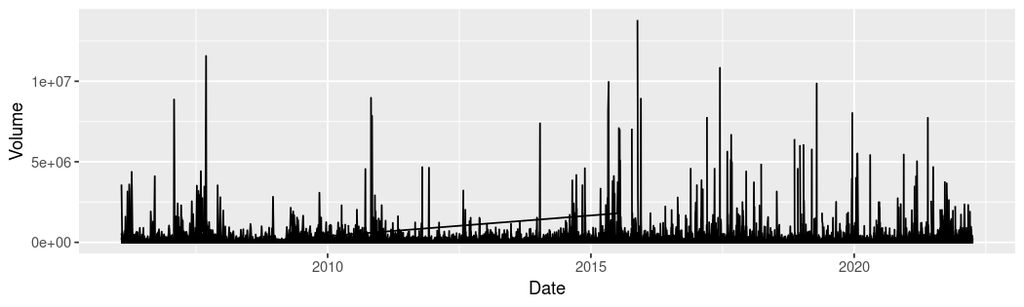

```r
# 画图
p <-  ggplot()
for (i in tail_5pct_mean_volume){
  p <- p + geom_line(data=stocks_all[[i]],aes(x=date,y=volume))
}
p <- p + labs(x="Date", y="Volume")
p
```

### 平均月股价排序

我们将所有股票按月平均股价排序，找出排末位5%的股票进行展示。

```r
mean_price <- to_vec(for (df in stocks_all) mean(df$close,na.rm=TRUE))
tail_5pct_mean_price <- which(mean_price < quantile(mean_price, probs=c(0.05), na.rm=TRUE))
all_symbols[tail_5pct_mean_price]
```

```
  [1] "01074.HK" "01097.HK" "01107.HK" "01147.HK" "01165.HK" "01172.HK" "01173.HK" "01189.HK" "01215.HK" "01217.HK" "01220.HK"
 [12] "01222.HK" "01250.HK" "01315.HK" "01335.HK" "01340.HK" "01421.HK" "01433.HK" "01439.HK" "00149.HK" "01545.HK" "01549.HK"
 [23] "01555.HK" "00156.HK" "01575.HK" "01580.HK" "01591.HK" "01621.HK" "01690.HK" "01695.HK" "01699.HK" "01718.HK" "01732.HK"
 [34] "01737.HK" "01742.HK" "01750.HK" "01792.HK" "01826.HK" "01854.HK" "01889.HK" "01891.HK" "01920.HK" "00204.HK" "00209.HK"
 [45] "02110.HK" "02129.HK" "02178.HK" "02212.HK" "02230.HK" "02263.HK" "02309.HK" "02326.HK" "00234.HK" "00235.HK" "02358.HK"
 [56] "02381.HK" "00248.HK" "00250.HK" "00254.HK" "00261.HK" "00265.HK" "02682.HK" "00269.HK" "02728.HK" "02909.HK" "02919.HK"
 [67] "02922.HK" "02924.HK" "00295.HK" "00313.HK" "00353.HK" "00361.HK" "00362.HK" "00383.HK" "03830.HK" "03889.HK" "04836.HK"
 [78] "00498.HK" "00515.HK" "00521.HK" "00526.HK" "06063.HK" "06108.HK" "06162.HK" "00621.HK" "00627.HK" "00063.HK" "00660.HK"
 [89] "00673.HK" "00680.HK" "00681.HK" "00690.HK" "00007.HK" "00720.HK" "00723.HK" "00755.HK" "00076.HK" "00760.HK" "00768.HK"
[100] "00789.HK" "00804.HK" "00809.HK" "00865.HK" "00904.HK" "00905.HK" "00092.HK" "00928.HK" "09608.HK" "00982.HK" "09918.HK"
[111] "09929.HK" "00993.HK"
```

从下图可以看出，这些股票的价格极少超过3HKD。通常它们被谑称为“仙股”。

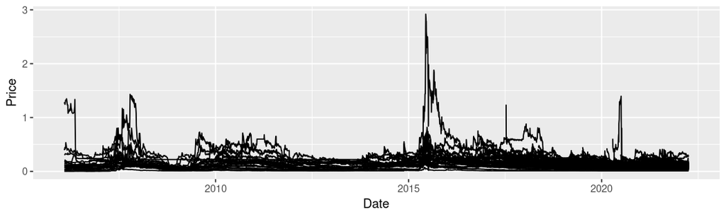

```r
# 画图
p <-  ggplot()
for (i in tail_5pct_mean_price){
  p <- p + geom_line(data=stocks_all[[i]],aes(x=date,y=close))
}
p <- p + labs(x="Date", y="Price")
p
```

### 最高月股价排序

我们将所有股票按最高月股价排序，找出前1%的股票进行展示。

```r
max_price <- to_vec(for (df in stocks_all) max(df$close,na.rm=TRUE))
head_1pct_max_price <- which(max_price > quantile(max_price, probs=c(0.99), na.rm=TRUE))
all_symbols[head_1pct_max_price]
```

```
 [1] "01003.HK" "01166.HK" "01194.HK" "00136.HK" "02324.HK" "00276.HK" "00326.HK" "00388.HK" "00397.HK" "00471.HK" "00572.HK"
[12] "00061.HK" "00616.HK" "00700.HK" "00736.HK" "00764.HK" "09011.HK" "00913.HK" "00959.HK" "09626.HK" "00985.HK" "00986.HK"
[23] "09987.HK"
```

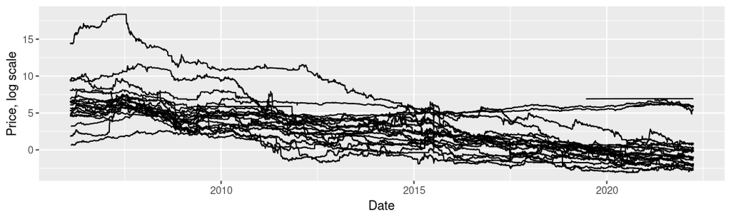

```r
# 画图
p <-  ggplot()
for (i in head_1pct_max_price){
  p <- p + geom_line(data=stocks_all[[i]],aes(x=date,y=log(close)))
}
p <- p + labs(x="Date", y="Price, log scale")
p
```

按最高月股价排序，末5%的股票：

```r
tail_5pct_max_price <- which(max_price < quantile(max_price, probs=c(0.05), na.rm=TRUE))
all_symbols[tail_5pct_max_price]
```

```
  [1] "01074.HK" "01097.HK" "01107.HK" "01116.HK" "01147.HK" "01162.HK" "01165.HK" "01173.HK" "01189.HK" "01220.HK" "01222.HK"
 [12] "01250.HK" "01315.HK" "01335.HK" "01340.HK" "01399.HK" "01413.HK" "01421.HK" "01433.HK" "01439.HK" "00149.HK" "01529.HK"
 [23] "01545.HK" "01549.HK" "01555.HK" "00156.HK" "01575.HK" "01580.HK" "01591.HK" "01620.HK" "01621.HK" "01699.HK" "01718.HK"
 [34] "01732.HK" "01737.HK" "01742.HK" "01750.HK" "01777.HK" "01792.HK" "01826.HK" "01854.HK" "01869.HK" "01889.HK" "01891.HK"
 [45] "01900.HK" "01920.HK" "00201.HK" "02031.HK" "00204.HK" "00209.HK" "02102.HK" "02110.HK" "02129.HK" "02132.HK" "02212.HK"
 [56] "02230.HK" "02263.HK" "00234.HK" "02381.HK" "00250.HK" "00254.HK" "00261.HK" "02682.HK" "00269.HK" "00279.HK" "02909.HK"
 [67] "02914.HK" "02919.HK" "02920.HK" "02922.HK" "02924.HK" "00295.HK" "00353.HK" "00359.HK" "00361.HK" "00362.HK" "03830.HK"
 [78] "03889.HK" "00399.HK" "04836.HK" "00498.HK" "00521.HK" "00526.HK" "00527.HK" "00542.HK" "06038.HK" "06108.HK" "06162.HK"
 [89] "00627.HK" "00063.HK" "00064.HK" "00673.HK" "00680.HK" "00690.HK" "00007.HK" "00723.HK" "00073.HK" "00755.HK" "00076.HK"
[100] "00789.HK" "00804.HK" "00809.HK" "00865.HK" "00897.HK" "00904.HK" "00905.HK" "00092.HK" "00928.HK" "09608.HK" "09918.HK"
[111] "09929.HK" "00993.HK"
```

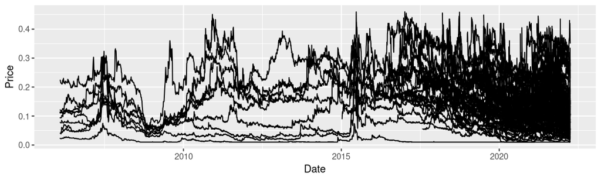

```r
# 画图
p <-  ggplot()
for (i in tail_5pct_max_price){
  p <- p + geom_line(data=stocks_all[[i]],aes(x=date,y=close))
}
p <- p + labs(x="Date", y="Price")
p
```

### 最低月股价排序

我们将所有股票按月最低股价排序，找出末1%的股票进行展示。

```r
min_price <- to_vec(for (df in stocks_all) min(df$close,na.rm=TRUE))
tail_1pct_min_price <- which(min_price < quantile(min_price, probs=c(0.01), na.rm=TRUE))
all_symbols[tail_1pct_min_price]
```

```
 [1] "01217.HK" "00139.HK" "01532.HK" "01738.HK" "02112.HK" "02212.HK" "02326.HK" "00250.HK" "00261.HK" "00269.HK" "00273.HK"
[12] "02909.HK" "00310.HK" "00313.HK" "00372.HK" "04836.HK" "00559.HK" "00627.HK" "00707.HK" "00708.HK" "00076.HK" "00990.HK"
```

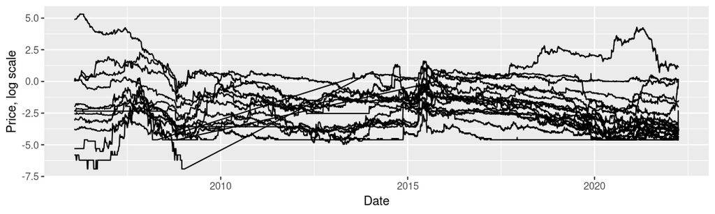

```r
# 画图
p <-  ggplot()
for (i in tail_1pct_min_price){
  p <- p + geom_line(data=stocks_all[[i]],aes(x=date,y=log(close)))
}
p <- p + labs(x="Date", y="Price, log scale")
p
```

### 最高最低价比值排序

我们将所有股票按最高最低价比值排序，找出前1%的股票进行展示。

```r
maxmin_ratio_price <- to_vec(for (df in stocks_all) max(df$close,na.rm=TRUE)/min(df$close,na.rm=TRUE))
head_1pct_maxmin_ratio_price <- which(maxmin_ratio_price > quantile(maxmin_ratio_price, probs=c(0.99), na.rm=TRUE))
all_symbols[head_1pct_maxmin_ratio_price]
```

```
 [1] "01003.HK" "01166.HK" "01194.HK" "01738.HK" "02324.HK" "02326.HK" "00273.HK" "00326.HK" "00397.HK" "00471.HK" "00572.HK"
[12] "00061.HK" "00616.HK" "00689.HK" "00708.HK" "00736.HK" "00764.HK" "00901.HK" "00913.HK" "00943.HK" "00959.HK" "00986.HK"
[23] "00997.HK"
```

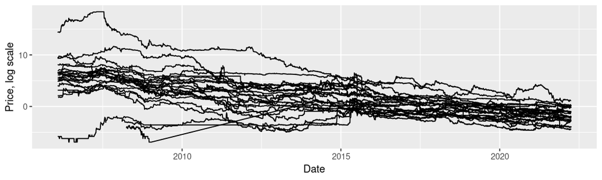

```r
# 画图
p <-  ggplot()
for (i in head_1pct_maxmin_ratio_price){
  p <- p + geom_line(data=stocks_all[[i]],aes(x=date,y=log(close)))
}
p <- p + labs(x="Date", y="Price, log scale")
p
```

## 日回报

将前面提到的股价异常的股票（平均月交易量排序末5%，平均月股价排序末5%，最高月股价排序末5%）排除后，我们对剩下每一支股票的日回报$r_t$的分布进行统计分析。

$$r_t \equiv {\rm log}(P_t/P_{t-1}) = {\rm
diff}({\rm log}(P))_t$$

```r
# 计算日回报
difflog <- function(x){return(diff(log(x)))}
```

### 例

例如，HK.00005的日回报分布为

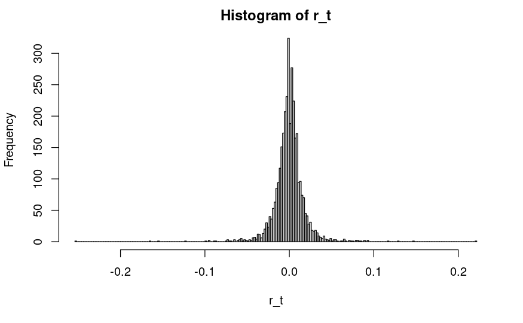

```r
P   <- na.omit(stocks_all[all_symbols=="00005.HK"][[1]]$close)
r_t <- difflog(P)
hist(r_t,breaks=200)
```

这个$r_t$分布的平均值看上去接近零，但分布似乎不对称，而且不太像正态分布。做一下 Shapiro-Wilk normality test 发现 p-value 几乎是零：

```r
shapiro.test(r_t)
```

```
    Shapiro-Wilk normality test

data:  r_t
W = 0.82768, p-value < 2.2e-16
```

再算一下 skew 和 kurtosis，发现离正态分布的值差很远：

```r
c(timeDate::skewness(r_t,method="moment",na.rm=T),
  timeDate::kurtosis(r_t,method="moment",na.rm=T))
```

```
[1] -0.3652538 30.5335139
```

我们并没有理由认为$r_t$是正态分布。这一点我会在别处讨论。纯粹出于好奇，我想再`diff`一下…

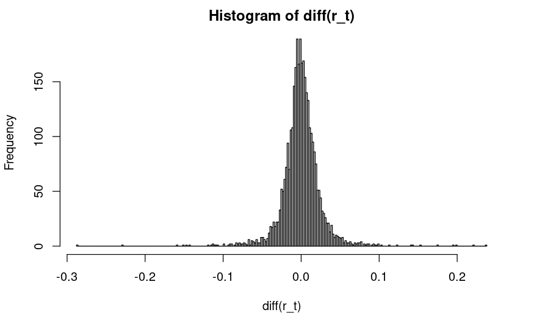

```r
hist(diff(r_t),breaks=200)
```

```r
c(timeDate::skewness(diff(r_t),method="moment",na.rm=T),
  timeDate::kurtosis(diff(r_t),method="moment",na.rm=T))
```

```
[1]  0.008307612 20.578172155
```

可以看到，skewness没了，但是kurtosis还在而且不小。

关于kurtosis需要澄清。它实际上是分布的四阶矩，但有不同的定义。查看`timeDate`库对应代码，我知道这个库计算kurtosis是用的下面的定义：

```r
    # Kurtosis:
    n = length(x)
    if (is.integer(x)) x = as.numeric(x)
    if (method == "excess") {
        kurtosis = sum((x-mean(x))^4/as.numeric(var(x))^2)/length(x) - 3
    }
    if (method == "moment") {
        kurtosis = sum((x-mean(x))^4/as.numeric(var(x))^2)/length(x)
    }
    if (method == "fisher") {
        kurtosis = ((n+1)*(n-1)*((sum(x^4)/n)/(sum(x^2)/n)^2 -
            (3*(n-1))/(n+1)))/((n-2)*(n-3))
    }
```

$${\rm
kurtosis}(x)=\frac{\overline{(x-\overline{x})^{4}}}{(\overline{x^2}-{\overline
x}^2)^2}$$
它实际上是用二阶矩归一化后的四阶矩。另外啰嗦一句，

```r
kurtosis = sum((x-mean(x))^4/as.numeric(var(x))^2)/length(x)
```

写成

```r
kurtosis = sum((x-mean(x))^4)/(as.numeric(var(x))^2)/length(x)
```

run的更快^_^

`timeDate::skewness`函数对应代码、公式如下：

```r
    # Skewness:
    n = length(x)
    if (is.integer(x)) x = as.numeric(x)

    # Selected Method:
    if (method == "moment") {
        skewness = sum((x-mean(x))^3/sqrt(as.numeric(var(x)))^3)/length(x)
    }
    if (method == "fisher") {
        if (n < 3)
            skewness = NA
        else
            skewness = ((sqrt(n*(n-1))/(n-2))*(sum(x^3)/n))/((sum(x^2)/n)^(3/2))
    }
```

$${\rm
skewness}(x)=\frac{\overline{(x-\overline{x})^{3}}}{(\overline{x^2}-{\overline
x}^2)^{3/2}}$$

### Kurtosis分布

将平均月交易量排序末5%，平均月股价排序末5%，最高月股价排序末5%排除后，我们对剩下每一支股票的日回报$r_t$的Kurtosis进行统计，代码和结果如下：

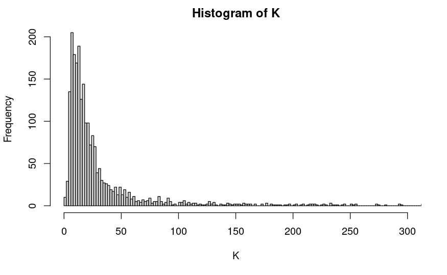

```r
h_95pct_mean_p <- which(mean_price  > quantile(mean_price,  probs=c(0.95), na.rm=TRUE))
h_95pct_mean_v <- which(mean_volume > quantile(mean_volume, probs=c(0.95), na.rm=TRUE))
h_95pct_max_p  <- which(max_price   > quantile(max_price,   probs=c(0.95), na.rm=TRUE))
K <- to_vec(for (st in stocks_all[(h_95pct_mean_p & h_95pct_mean_v) & h_95pct_max_p])
            timeDate::kurtosis(difflog(st$close),method="moment",na.rm=T))
hist(K,breaks=800,xlim=c(0,300))
```

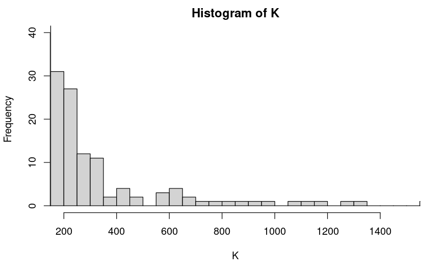

```r
hist(K,breaks=40,xlim=c(200,1500),ylim=c(0,40))
```

### Skewness分布

将平均月交易量排序末5%，平均月股价排序末5%，最高月股价排序末5%排除后，我们对剩下每一支股票的日回报$r_t$的skewness进行统计，代码和结果如下：

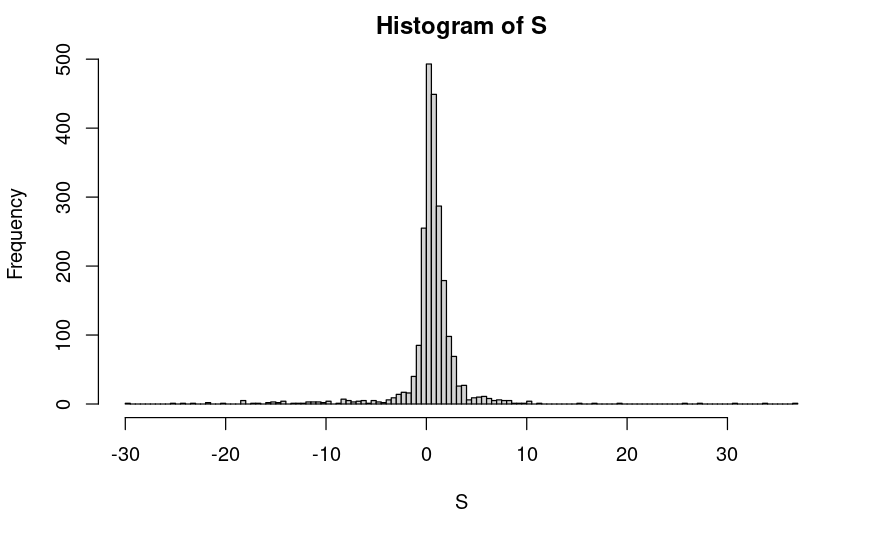

```r
h_95pct_mean_p <- which(mean_price  > quantile(mean_price,  probs=c(0.95), na.rm=TRUE))
h_95pct_mean_v <- which(mean_volume > quantile(mean_volume, probs=c(0.95), na.rm=TRUE))
h_95pct_max_p  <- which(max_price   > quantile(max_price,   probs=c(0.95), na.rm=TRUE))
S <- to_vec(for (st in stocks_all[(h_95pct_mean_p & h_95pct_mean_v) & h_95pct_max_p])
            timeDate::skewness(difflog(st$close),method="moment",na.rm=T))
hist(S,breaks=100)
```

可以看到，skewness整体偏向一个正数，也就是说，很多支股票价格的 log daily return $r_t$ 是偏向大于均值一侧的。 我们来试着理解这个现象。首先，log daily return 与通常的 daily return 并不相同。试比较：

$$r_t \equiv {\rm log}(P_t/P_{t-1}) = {\rm
diff}({\rm log}(P))_t$$

$$q_t \equiv (P_t/P_{t-1} - 1)$$
考虑连续三个价格 $P_{t+1}=a$, $P_{t}=b$, $P_{t-1}=a$ 且 $b<a$。以$q_t$来衡量日收益：

$$q_{t+1}=a/b-1,\;q_t=b/a-1.$$

对于$b<a$，我们总有$(a/b-1)>(1-b/a)$，也就是说，在股票下跌一定比例之后，如果接下来涨回原价格，那么涨幅一定大于跌幅。然而，以$r_t$来衡量日收益，并不会有这种现象：

$$r_{t+1}={\rm log}(a/b),\;r_t={\rm
log}(b/a)\equiv-r_{t+1}.$$

那么，我们观察到$r_t$系统地偏向均值之上，就说明这只股票的价格整体上处于上升状态。

# 财富密码？港股的迷惑行为

最后让我们来观赏一下股价异常的港股的迷惑行为。我们把行为相似的股票合并在一起展示。

## 扑街组：股价一直很低

按最高月股价排序垫底的10支股票及最高股价：

```r
bottom10_max_price <- order(max_price)[1:10]
data.frame(
  symbol=all_symbols[bottom10_max_price],
  max.price=max_price[bottom10_max_price])
```

| symbol | max.price |
| --- | --- |
| 02909.HK | 0.010 |
| 00627.HK | 0.028 |
| 00526.HK | 0.053 |
| 00723.HK | 0.057 |
| 02919.HK | 0.059 |
| 00076.HK | 0.066 |
| 00353.HK | 0.071 |
| 01439.HK | 0.074 |
| 00261.HK | 0.075 |
| 00755.HK | 0.079 |

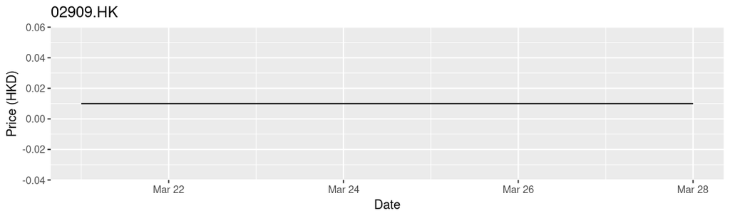

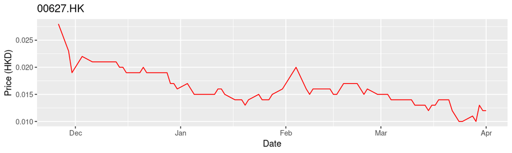

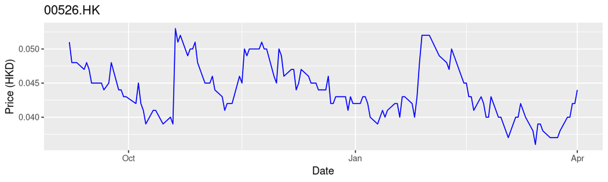

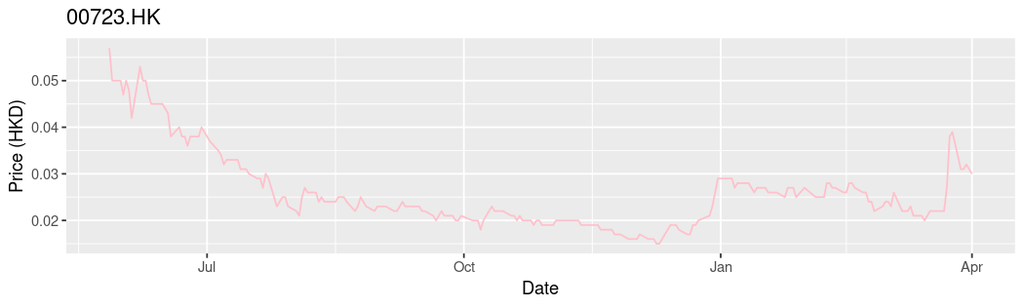

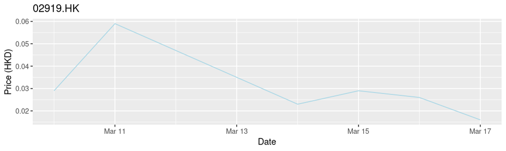

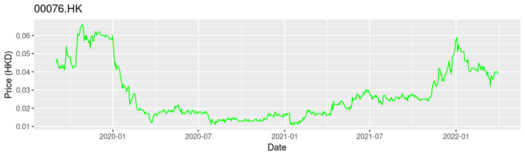

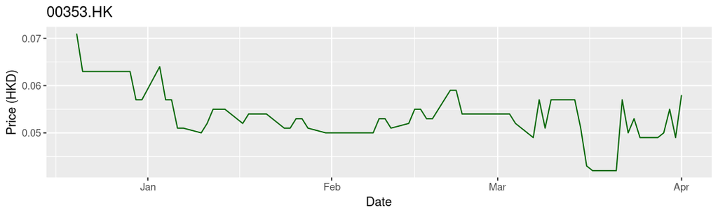

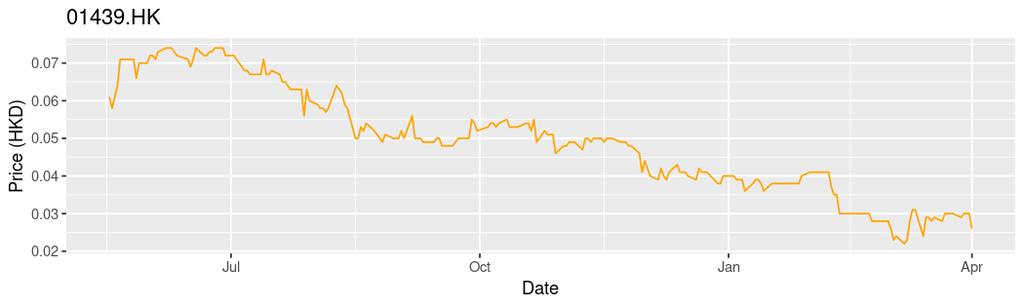

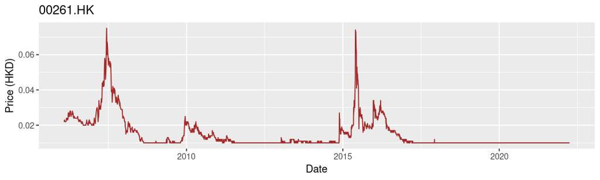

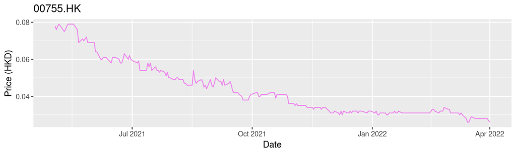

```r
# 画图
col10 <- c("black","red","blue","pink","lightblue",
           "green","darkgreen","orange","brown","violet")
c <- 1
for (i in bottom10_max_price){
  p <- ggplot() +
       geom_line(data=stocks_all[[i]],aes(x=date,y=close),color=col10[[c]]) +
       labs(x="Date", y="Price (HKD)") +
       ggtitle(all_symbols[[i]])
  print(p)
  c <- c+1
}
```

## 暴富组：暴涨后暴跌然后静止

按最高月股价/最低月股价比值排序最前的10支股票及比值：

```r
extreme10_maxmin_ratio <- order(-maxmin_ratio_price)[1:10]
data.frame(
  symbol=all_symbols[extreme10_maxmin_ratio],
  ratio=maxmin_ratio_price[extreme10_maxmin_ratio])
```

| symbol | ratio |
| --- | --- |
| 00616.HK | 894412523.36 |
| 00736.HK | 409436.21 |
| 00913.HK | 252931.40 |
| 01166.HK | 78456.61 |
| 00986.HK | 56096.07 |
| 00764.HK | 35117.28 |
| 00273.HK | 29366.29 |
| 00061.HK | 17721.15 |
| 00397.HK | 10677.46 |
| 00943.HK | 10380.33 |

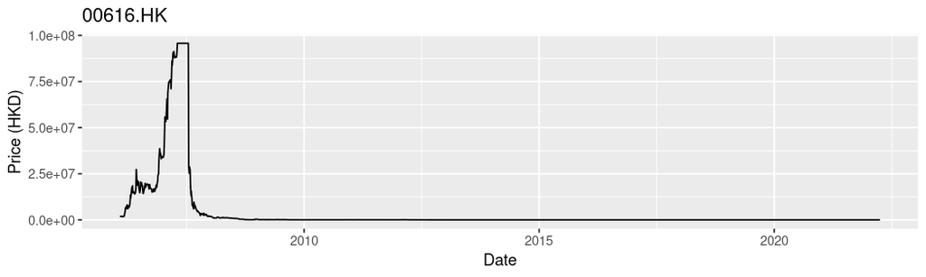

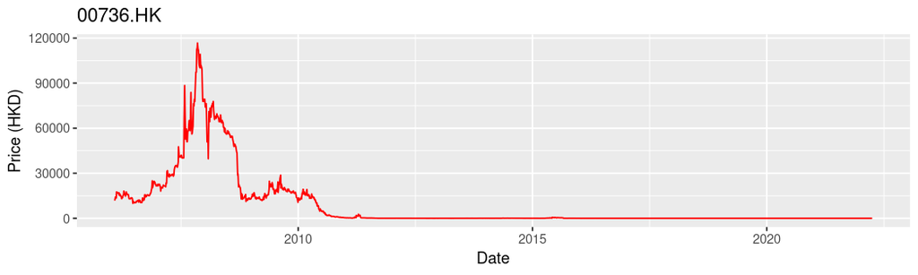

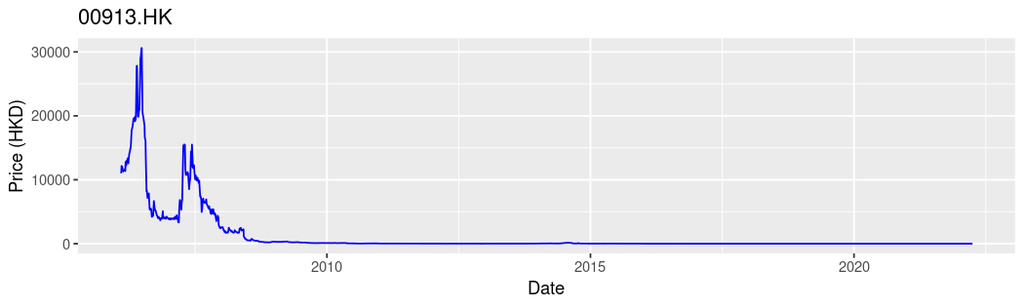

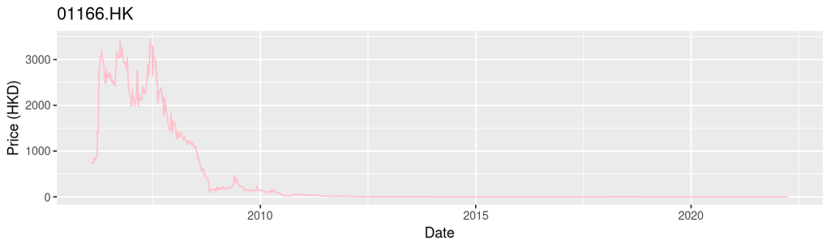

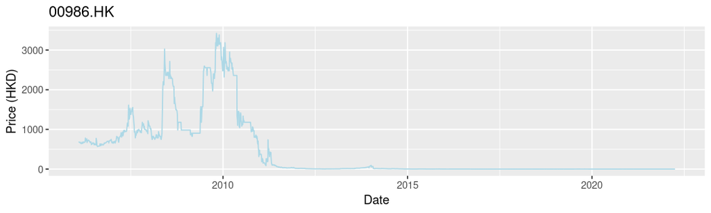

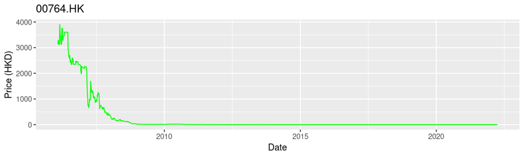

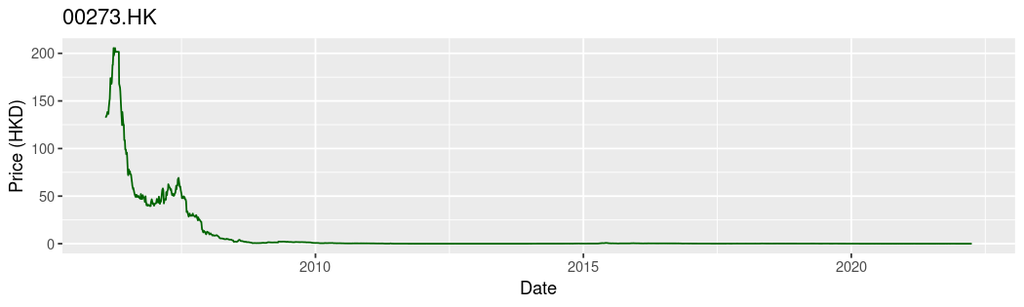

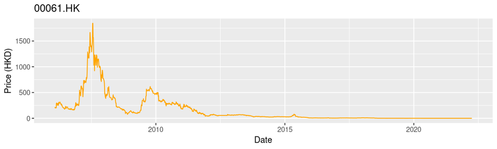

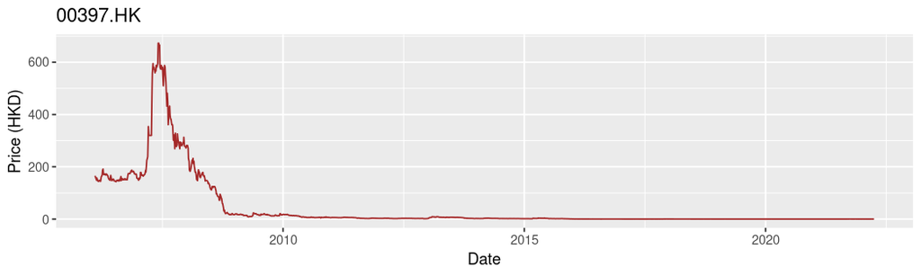

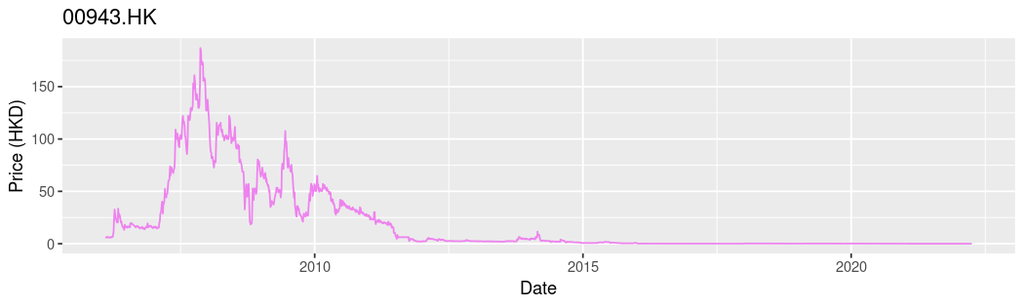

```r
# 画图
col10 <- c("black","red","blue","pink","lightblue",
           "green","darkgreen","orange","brown","violet")
c <- 1
for (i in extreme10_maxmin_ratio){
  p <- ggplot() +
       geom_line(data=stocks_all[[i]],aes(x=date,y=close),color=col10[[c]]) +
       labs(x="Date", y="Price (HKD)") +
       ggtitle(all_symbols[[i]])
  print(p)
  c <- c+1
}
```